# QTM 151 - Quiz 1

## Try to submit as an HTML file

Print your name below

```python
# Write your answer here

print("Joanna Gould")
```

```
Joanna Gould
```

This quiz is open book

- You can use the lecture notes
- You will get partial credit for attempting the questions
- To get full credit, the code should work as intended
- You should NOT communicate with other students

Print the following message:

"I will abide by Emory's code of conduct"

```python
# Write your answer here:

print("I will abide by Emory's code of conduct")
```

```
I will abide by Emory's code of conduct
```

Import the libraries "numpy", "matplotlib.pytplot", and "pandas"

```python
# Write your answer here

import numpy as np
import matplotlib.pyplot as plt
import pandas as pd
```

(a) IF/ELSE statements

- Create two lists:

`list_p = ["Introduction","to","Python"]`  
`list_r = ["Intro","to","R"]`

- Create a new variable `keyword = "Introduction"`
- Create an if/else that tests whether `keyword` is part of either

list. Print your a message (you choose which message) if the test is true.

HINT: Use the "in" command to test whether an element is part  
of a list (see Lecture 4)

```python
# Write your answer here:

list_p = ["Introduction","to","Python"]
list_r = ["Intro","to","R"]

keyword = "Introduction"

if (keyword in list_p) | (keyword in list_r):
    print("The test is true")
```

```
The test is true
```

(a) Transform a list of values and plot it

- Create an array with the following values

`coord_x = [1,4, 0, -1, 20, 40]`

`coord_y = [2,2, 0, 10, 0, 1]`

- Create a new vector `hypotenuse` with the following formula

$\qquad hypotenuse = x^2 + y^2$

- Produce a histogram of the variable hypotenuse
- Label the axes and the title
- Change the color to "orange", "green" or "purple" (you choose)

Hint: You can use numpy functions

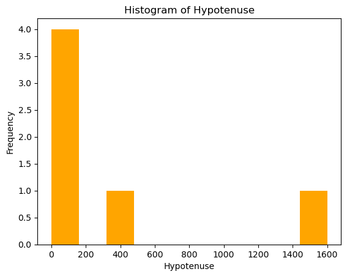

```python
# Write your answer here:

coord_x = [1,4, 0, -1, 20, 40]
coord_y = [2,2, 0, 10, 0, 1]

hypotenuse = np.array(coord_x)**2 + np.array(coord_y)**2

plt.hist(hypotenuse, color='orange')
plt.xlabel('Hypotenuse')
plt.ylabel('Frequency')
plt.title('Histogram of Hypotenuse')
plt.show()
```

(c) Plot random variables ...

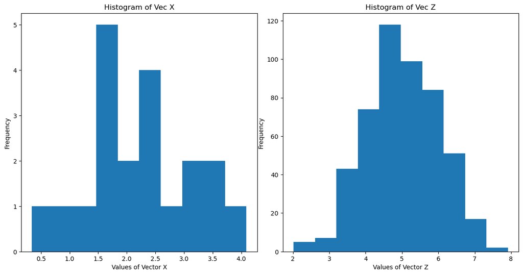

```python
# Write your answer here:

n = 500
vec_x = np.random.normal(loc = 2, scale = 1, size = 20)
vec_z = np.random.normal(loc = 5, scale = 1, size = n)

fig, list_subfig = plt.subplots(1, 2, figsize=(12, 6))

plt.tight_layout()

list_subfig[0].hist(vec_x)
list_subfig[0].set_xlabel('Values of Vector X')
list_subfig[0].set_ylabel('Frequency')
list_subfig[0].set_title('Histogram of Vec X')

list_subfig[1].hist(vec_z)
list_subfig[1].set_xlabel('Values of Vector Z')
list_subfig[1].set_ylabel('Frequency')
list_subfig[1].set_title('Histogram of Vec Z')
```

(d) Combine information across datasets

- Read the dataset "/data_quiz/germany_co2_emissions.csv" and store it as "data_germany"
- View the dataset, and see what variables it contains
- Plot a figure on CO2 emissions with the following characteristics
  - The yearly variable on the x-axis.
  - Plots of Germany's CO2 emissions on the y-axis.
  - Label the axes

```
    year  total_emissions
0   1990    955310.000000
1   1991    932550.000000
2   1992    892820.000000
3   1993    887060.000000
4   1994    875900.000000
5   1995    874660.000000
6   1996    904340.000000
7   1997    872650.000000
8   1998    865250.000000
9   1999    833590.000000
10  2000    830280.000000
11  2001    847680.000000
12  2002    833380.004883
13  2003    836789.978027
```

[output cut: 16 more lines]

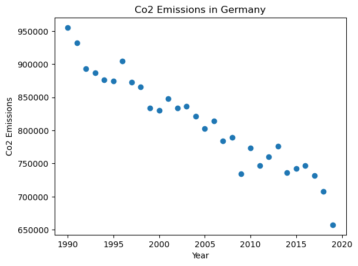

```python
# Write your answer here:

data_germany = pd.read_csv("./data_quiz/germany_co2_emissions.csv")

print(data_germany)

plt.scatter(data_germany['year'], data_germany['total_emissions'])
plt.title("Co2 Emissions in Germany")
plt.xlabel("Year")
plt.ylabel("Co2 Emissions")
plt.show()
```

(e) Loop through dfferent variables and plot

- Read the dataset "data_quiz/wdi_ageprop_2020.csv"
- Create a list of variable names with the following elements:

`list_varnames = ["percent_ages0to14","percent_ages15to64"]`

- Run a for loop that computes the mean for each variable and print it on screen.

```python
# Write your answer here:

age_prop = pd.read_csv("./data_quiz/wdi_ageprop_2020.csv")

list_varnames = ["percent_ages0to14", "percent_ages15to64"]

for varnames in list_varnames:
    print(age_prop[varnames].mean())
```

```
26.90657125728302
63.68465159973585
```

(f) Run loop through different datasets and compute statistics

- Create a list with the ".csv" dataset names of two countries. For example,

`["data_quiz/name1.csv","data_quiz/name2.csv"]`

- Create an empty list called `list_emissions`
- Run a for-loop over the list of dataset names. Inside the loop:
  - Read the corresponding ".csv" dataset.
  - Compute the mean of "total_emissions" for each respective country,

  and store it as an element of `list_emissions`
- Print `list_emissions`

HINT: Use `.append()` (See Lecture 5)

```python
# Write your answer here:

list1 = ("./data_quiz/germany_co2_emissions.csv", "./data_quiz/china_co2_emissions.csv")

list_emissions = list()

for file in list1:
    data = pd.read_csv(file)
    list_emissions.append(data['total_emissions'].mean())

print(list_emissions)
```

```
[812234.0017903647, 3599957.523613542]
```